# STA141B Code Report

## Introduction

The Davis Labor Day Running Races stand as an important annual event, attracting participants with its athleticism and community spirit. This code report will provide the analysis of data associated with these races, finding valuable insights and patterns within the information. By employing web scraping techniques, we gather data directly from the event's official website, ensuring accuracy and up-to-date information for our analysis.

Our scraping website can be found at [this link](https://results.changeofpace.com/results.aspx?CId=16356&RId=6121&EId=1).

## Methodology

To construct our dataset, we employ web scraping using Python, utilize libraries such as BeautifulSoup and requests. The script navigates through the structure of the Davis Labor Day Running Races website, extracting information such as participant names, participant age, time the participant spent to finish the race, gender, race type(5K/10K), and year of the race held. Once gathered, the data is organized and transformed into a structured CSV file, ensuring accessibility for subsequent analysis. This approach allows us to automate the data retrieval process, facilitating efficiency for future analysis by avoiding rescraping the data from the website. The analysis section of this report will delve into the exploratory data analysis and plots derived from the acquired dataset and provide readers with the performance and trends observed in the Davis Labor Day Running Races. (For the code of scraping, see appendix)

Our processed data can be found at [this link](https://github.com/hubao666/STA141B_Final_Project/blob/main/data/processed.csv).

### Getter (helper) Functions Implementations

This chunk of code consists of helper functions that return our desired value from the table in the website. For example, participant's name, age, and finish time, ect. There will be a construct function that generates dataframe by calling these helper functions. By observed, all helper functions require `response` as argument, and some of them expect `year`.

### Here is how each helper funciton work

1. Convert the response (HTML file) into a Beautiful Soup object.
2. Find all the matching values by using `find_all()` function from the html file. Matched values are the texts in the html file that we are interested in
   - We identify the tag and class of the desired texts using Chrome's developer tools, and then specify them in the function to obtain our result.
3. For each value in the list of matched values
   - Extract the content by using beautiful soup object's `get_text()` function
   - Append the content to a list
4. After we have a list of content, convert the list to pandas series object
5. Filter out irrelevant content from the dataframe. Irrelevant information were captured because they share the same tag and class in the html file, and were captured in step `2` where we used `find_all()` function.
   - We observe the pattern of occurrence for the desired contents, and for each type of information (age, finish time, etc.), the patterns are different. More details about this are provided below.
   - The same information in different years might be rendered differently, so some helper functions take the `year` as a parameter to extract the desired content accordingly.
6. Reset the index
7. Return the series

### Possible questions for analysis and visualization

#### Main Topic: What factors will mostly affect the runnning endurance?

#### Analysis perspectives:

1. Pace (min/km)
2. Time spend to finish the race
3. Running distance
4. Gender
5. Covid (Due to the pandemic, the competition were not held in 2020 and 2021, we are trying to find if there are any difference in performance before and after the pandemic)

### Questions:

1. Which age group have the maximum and minimum pace？
2. For the same running distance (5k,10k), what is the speed difference between female and male within the same age group?
3. Before and after pandemic, is there a significant difference with the pace? If there is, explain it. What does this result tell us?
   - Gender speed and pace difference?
   - Age group speed and pace difference?

## Findings and Visualizations

## Q1

### Which age group have the minimum and maximum average speed and pace?

#### Maximum average speed:

#### Average Speed for Each Age Group

| Age Group | Average Speed (Km/h) |
| --- | --- |
| 10 - 19 | 10.653362 |
| 20 - 29 | 10.378087 |
| 30 - 39 | 9.907945 |
| 40 - 49 | 9.608170 |
| 50 - 59 | 9.554777 |
| 60 - 69 | 8.376220 |
| 70 - 79 | 7.774164 |
| 80 - 89 | 6.743519 |
| < 10 | 8.523794 |
| > 90 | 6.396000 |

The age group for maximum average speed is 10 - 19  
The maximum average speed for 10 - 19 is 10.65336170212766  
The age group for minimum average speed is > 90  
The minimum average speed for > 90 is 6.396000000000001

#### Maximum average pace:

#### Average Pace for Each Age Group

| Age Group | Average Pace (min/Km) |
| --- | --- |
| 10 - 19 | 6.135798 |
| 20 - 29 | 6.259797 |
| 30 - 39 | 6.559876 |
| 40 - 49 | 6.751231 |
| 50 - 59 | 6.803352 |
| 60 - 69 | 7.724759 |
| 70 - 79 | 8.225527 |
| 80 - 89 | 9.491926 |
| < 10 | 7.656850 |
| > 90 | 9.661333 |

The age group for maximum average pace is > 90  
The maximum average pace for > 90 is 9.661333333333333  
The age group for minimum average pace is 10 - 19  
The minimum average pace for 10 - 19 is 6.135797872340425

## Q2

### For the same running distance (5k,10k), what is the speed difference between female and male within the same age group?

### 5k distance gender difference:

#### Speed Difference between Female and Male for Each Age Group:

| Age Group | Speed Difference |
| --- | --- |
| 10 - 19 | 2.817 |
| 20 - 29 | 2.688 |
| 30 - 39 | 3.399 |
| 40 - 49 | 1.075 |
| 50 - 59 | 1.287 |
| 60 - 69 | 2.720 |
| 70 - 79 | 3.072 |
| 80 - 89 | 2.977 |
| < 10 | -0.851 |
| > 90 | 2.470 |

#### Pace Difference between Female and Male for Each Age Group:

| Age Group | Pace Difference |
| --- | --- |
| 10 - 19 | 0.323 |
| 20 - 29 | -0.190 |
| 30 - 39 | 2.186 |
| 40 - 49 | -0.014 |
| 50 - 59 | -5.043 |
| 60 - 69 | -1.050 |
| 70 - 79 | 0.010 |
| 80 - 89 | -1.454 |
| > 90 | -3.187 |

### 10k distance gender difference:

#### Speed Difference Between Female and Male for Each Age Group:

| Age Group | Speed Difference |
| --- | --- |
| 10 - 19 | 1.417 |
| 20 - 29 | 4.180 |
| 30 - 39 | 2.294 |
| 40 - 49 | 3.010 |
| 50 - 59 | 0.914 |
| 60 - 69 | 2.548 |
| 70 - 79 | 2.282 |
| 80 - 89 | 3.068 |
| < 10 | 3.041 |

#### Pace Difference between Female and Male for Each Age Group:

| Age Group | Pace Difference |
| --- | --- |
| 10 - 19 | 0.722 |
| 20 - 29 | -3.885 |
| 30 - 39 | -2.358 |
| 40 - 49 | -1.070 |
| 50 - 59 | -2.875 |
| 60 - 69 | -0.925 |
| 70 - 79 | 1.238 |
| 80 - 89 | -2.099 |
| < 10 | 0.966 |

## Q3.

### Before and after COVID epidemic (two year), is there a significant difference with the average speed and pace? If there is explain it, what does this result tell us? (before: 2018-2019 after: 2022-2023)

```
* Separate for difference distance (5k,10k)
* Gender speed and pace difference?
* Age group speed and pace difference?
```

### 5k distance difference:

#### Average Speed Difference between Female and Male:

| Gender | Average Speed Difference (Km/h) |
| --- | --- |
| Female | 0.005749 |
| Male | 0.153357 |
| No Answer | NaN |
| Non-Binary | NaN |

#### Average Pace Difference between Female and Male:

| Gender | Average Pace Difference (min/Km) |
| --- | --- |
| Female | -0.049368 |
| Male | -0.272540 |
| No Answer | NaN |
| Non-Binary | NaN |

#### Average Speed Difference for Each Age Group:

| Age Group | Average Speed Difference (Km/h) |
| --- | --- |
| 10 - 19 | -0.429759 |
| 20 - 29 | -0.171736 |
| 30 - 39 | 0.087056 |
| 40 - 49 | 0.655589 |
| 50 - 59 | 0.090198 |
| 60 - 69 | 0.153445 |
| 70 - 79 | -0.184722 |
| 80 - 89 | 0.466500 |
| < 10 | 0.068848 |
| > 90 | NaN |

### Analysis:

#### Average Pace Difference for Each Age Group:

| Age Group | Average Pace Difference (min/Km) |
| --- | --- |
| 10 - 19 | 0.116404 |
| 20 - 29 | 0.194068 |
| 30 - 39 | -0.173105 |
| 40 - 49 | -0.774715 |
| 50 - 59 | -0.080833 |
| 60 - 69 | -0.084070 |
| 70 - 79 | 0.025453 |
| 80 - 89 | -1.104250 |
| < 10 | -0.220780 |
| > 90 | NaN |

### 10k distance difference

#### Average Speed Difference between Female and Male:

| Gender | Average Speed Difference (Km/h) |
| --- | --- |
| Female | 0.186511 |
| Male | 0.245551 |
| Unknown | NaN |

#### Average Pace Difference between Female and Male:

| Gender | Average Pace Difference (min/Km) |
| --- | --- |
| Female | -0.224696 |
| Male | -0.102597 |
| Unknown | NaN |

#### Average Speed Difference for Each Age Group:

| Age Group | Average Speed Difference (Km/h) |
| --- | --- |
| 10 - 19 | -0.641071 |
| 20 - 29 | 0.681982 |
| 30 - 39 | 0.027174 |
| ... | ... |
| < 10 | NaN |

#### Average Pace Difference for Each Age Group:

[output not shown]

### Visualization

#### The boxplot for different age groups versus speed(km/h):

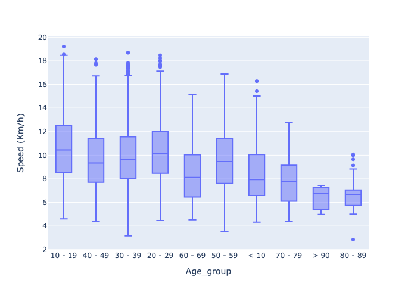

#### The boxplot for different age groups versus pace(min/km):

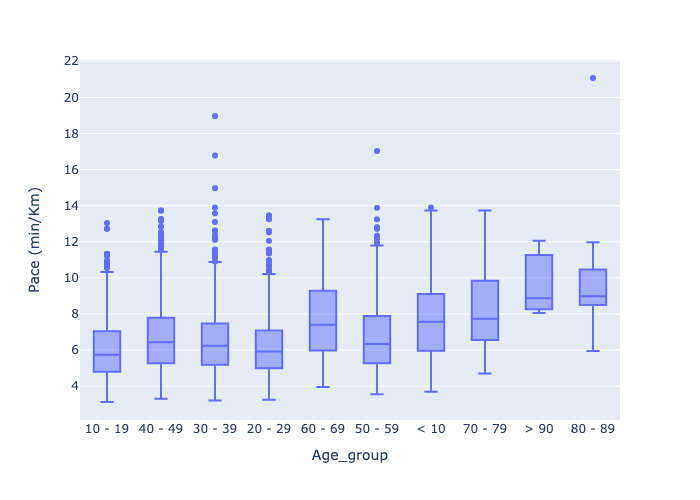

### Analysis:

- From the two boxplot above, we see participants in age group 10-19 have the fastest pace and highest speed in median. This corresponds to our analysis above that participants within age group 10-19 have the fastest average pace and highest average speed.
- Participants in age group 80-89 have the slowest pace and the lowest speed in medina. Even though our findings in the average pace and speed shows that participants in age group above 90 have the slowest pace and lowest speed, both finding indicates that older participants have weaker performances in running competitions.

#### The boxplot for gender versus speed(km/h):

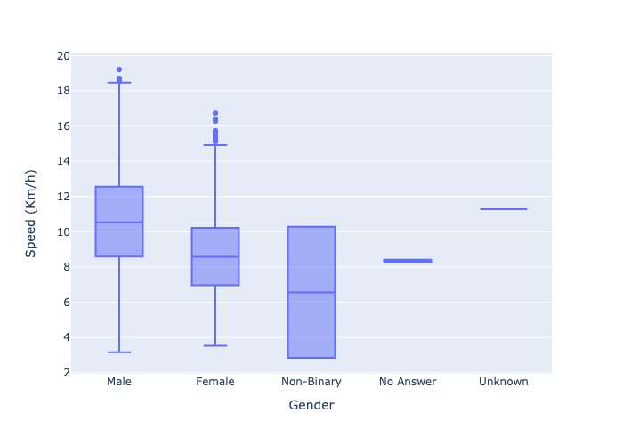

#### The boxplot for gender versus pace(min/km):

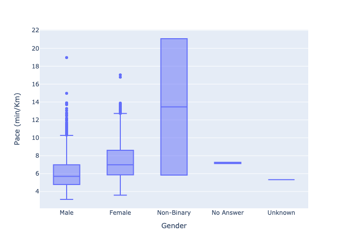

### Trendline and scatter plot

#### Trendline and scatter plot for speed

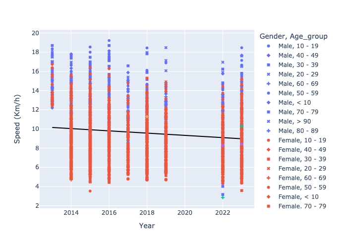

#### Trendline and scatter plot for pace

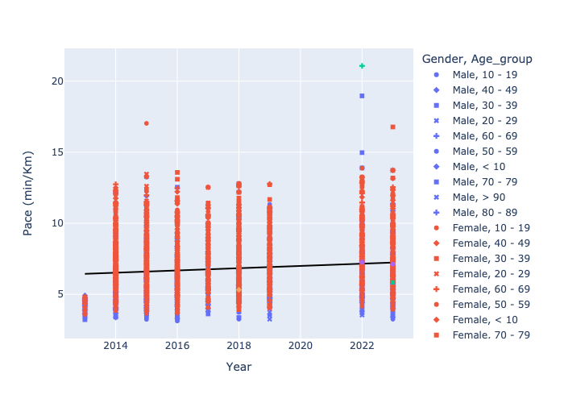

### Analysis:

- From first plot, we see there is a slight decrease in overall average speed from 2013 to 2023. We can also see people with higher speed are males among all age groups.
- From the second plot, we see there is a slight increase in overall average pace from 2013 to 2023. We can also see people with faster paces are males among all age groups.
- The highest speed in year 2022, the year after the pandemic, is lower than both the previous year and the upcoming year. This may indicates that the pandemic negatively influenced the exercise performance and endurance. Besides that, we don't see much difference in the highest speed and pace in other years.

## Problems faced and solutions

During the process of data scraping, when we test the dataframe we got from the website, we ended with result like this:

| Name | Age |
| --- | --- |
| Lisa Geibel-Finn | 744 |
| Christopher Kim | 799 |
| Carey Seal | 758 |
| Lenna Ontai | 655 |

Apparently, we didn't manage to capture the correct age values. There must be something wrong in the process of extracting desired age values. The thing that causes confusion is that the method we used in page 2 worked with no trouble, so we then observed the difference of the tables between 2 pages.

After observation, we found that there is a column named `Sp Div Pos`(stands for "Special Division Position") that share the same tag and class as the texts containing our desired age values. On the table from page 2, there is no value under this column, and in contrast, some of rows contain value under this column on the table from page 3. The occurence of the first value of `Sp Div Pos` ruins the pattern that "each `age value` is separated by `3` irrevelant values to the next `age value`", as the first `Sp Div Pos` value make the distance from 3 to 4. As a result, all the following data were captured incorrectly.

We then considered to eliminate the html text with the occurence of `Sp Div Pos` value, but since they share the exact same tag and class as the `age value` as mentioned serveral times above, we were not able to find a way to do that.

Once the first `Sp Div Pos` value occured, it means that one more irrevelant value appears between two age values since it's not a `NA`, and we didn't drop it.

The simplest way to fix it is that not to drop `NA`, instead, change the pattern that we extract the age values.

| Name | Age |
| --- | --- |
| Lisa Geibel-Finn | 58 |
| Christopher Kim | 53 |
| Carey Seal | 42 |
| Lenna Ontai | 50 |

Now we have sovled the problem! The names and ages match.